# Il COVID-19 ha influenzato la nostra felicità?

2022-09-01

## Introduzione

Lo scopo di questo studio è quello di analizzare se c’è stato un cambiamento nella felicità delle persone prima e dopo l’avvento del COVID-19 e la crisi che lo ha accompagnato.

Per far ciò sono stati analizzati i *World Happinness Report* dal 2015 al 2022.

**World Happiness Report**

Il *World Happiness Report* è una pubblicazione del Sustainable Development Solutions Network organizzato dal Gallup World Poll data che contiene articoli e classifiche della felicità nazionale dei vari stati del mondo, sulla base di interviste, e i fattori prevalenti che vengono analizzati sono:

- GDP per capita
- salute
- supporto sociale
- libertà
- fiducia nel governo
- generosità

percepiti dalle persone verso la propria comunità/nazione.

I report coinvolgono 153 stati e sono stati reperiti su Kaggle al seguente link [World Happiness Report up to 2022](https://www.kaggle.com/datasets/mathurinache/world-happiness-report?resource=download&select=2015.csv)

## La felicità prima del COVID-19

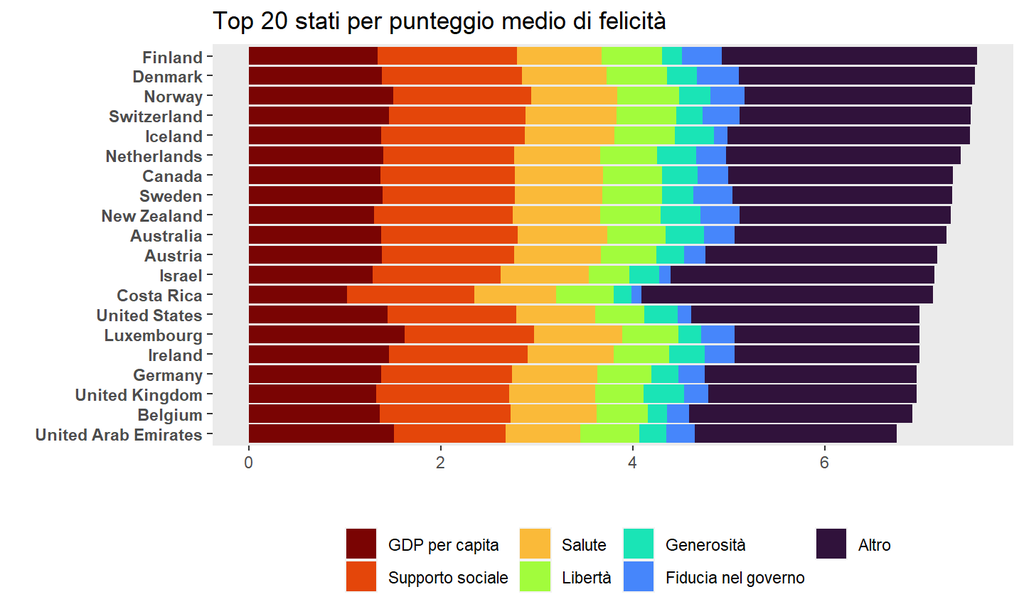

Gli stati più felici fanno parte del Nord Europa.

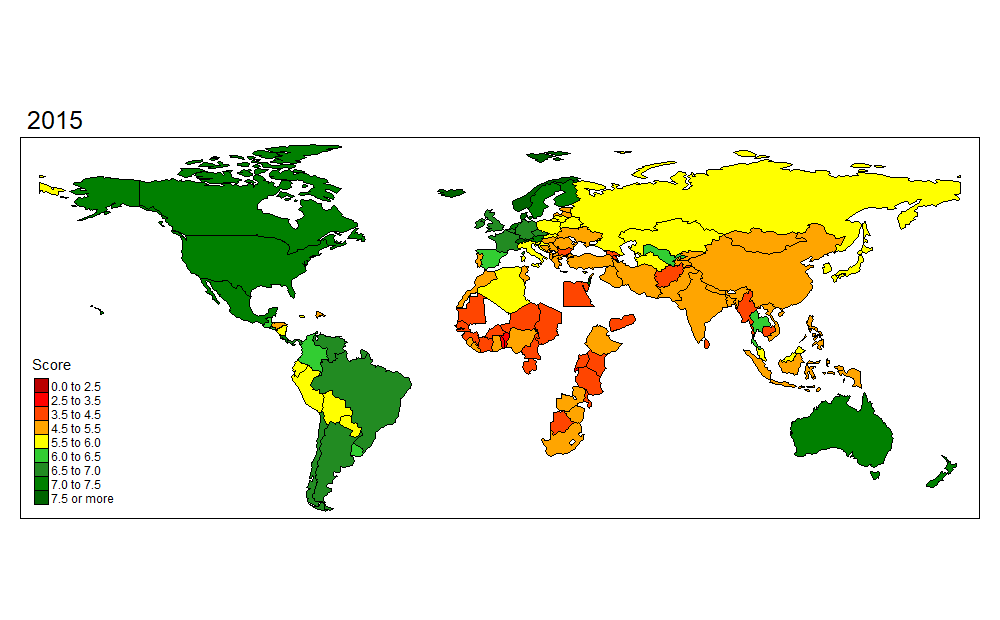

I continenti più felici sono Nord America, Nord Europa ed Oceania.

**Incremento della felicità**

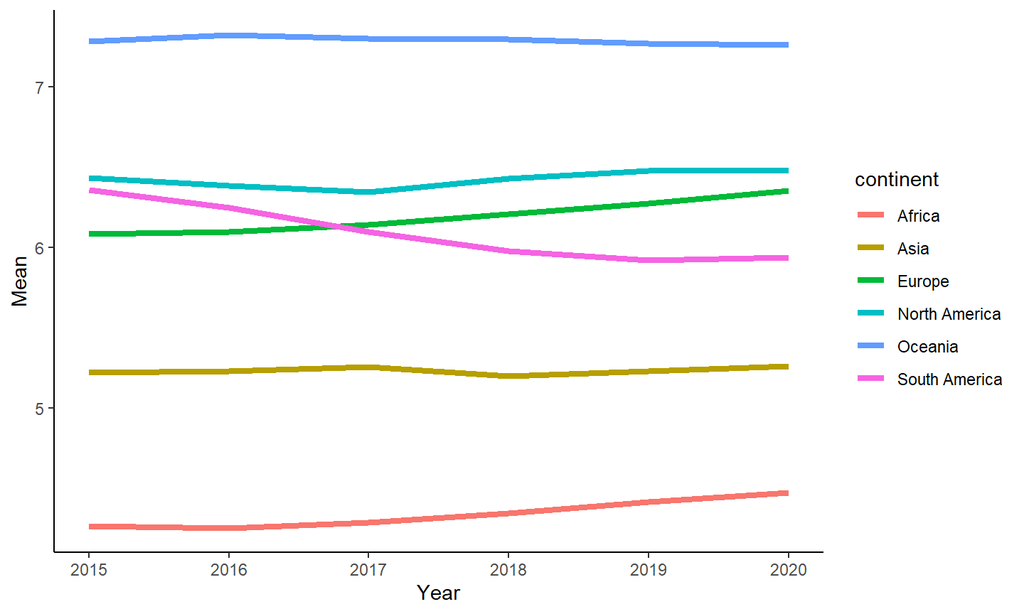

Il Sud America risulta aver avuto una decrescita significativa rispetto agli altri continenti che sono o aumentati o rimasti pressochè costanti.

```
# A tibble: 138 x 4
# Rowwise:  Country
   Country     `2015` `2020` Change
   <chr>        <dbl>  <dbl>  <dbl>
 1 Venezuela     6.81   5.05 -1.76
 2 Zambia        5.13   3.76 -1.37
 3 Zimbabwe      4.61   3.30 -1.31
 4 Afghanistan   3.58   2.57 -1.01
 5 India         4.57   3.57 -0.992
 6 Botswana      4.33   3.48 -0.853
 7 Malawi        4.29   3.54 -0.754
 8 Mexico        7.19   6.47 -0.722
 9 Brazil        6.98   6.38 -0.607
10 Algeria       5.60   5.01 -0.600
# ... with 128 more rows
```

Nota: il Venezuela sta subendo una crisi dal 2013 e ne ebbe una presidenziale nel 2019.

[figure not shown]

**Matrice di correlazione**

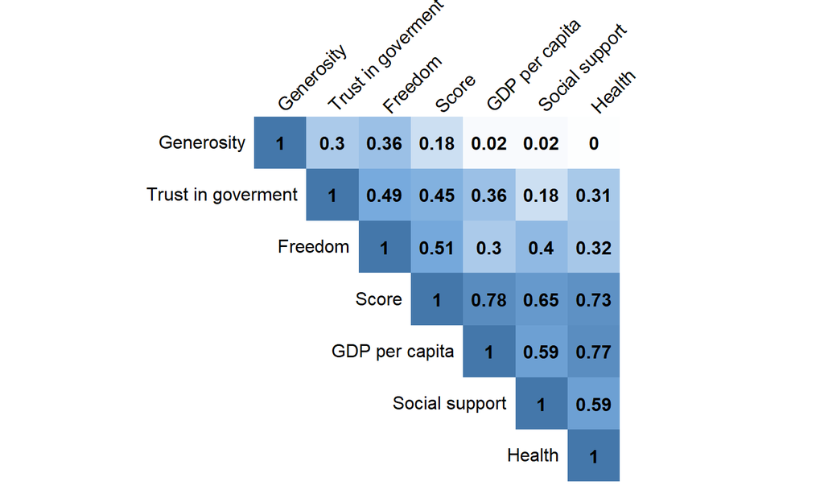

Prima del COVID-19 i 3 fattori che influenzavano maggiormente lo score della felicità erano:

- GDP per capita
- salute
- supporto sociale

## Andamento della felicità dopo il COVID-19

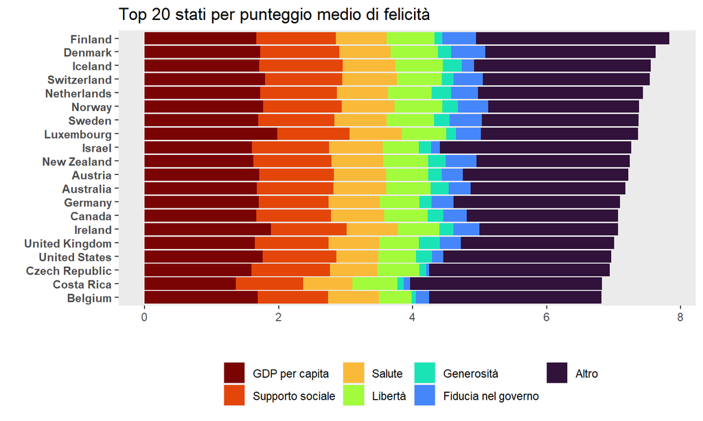

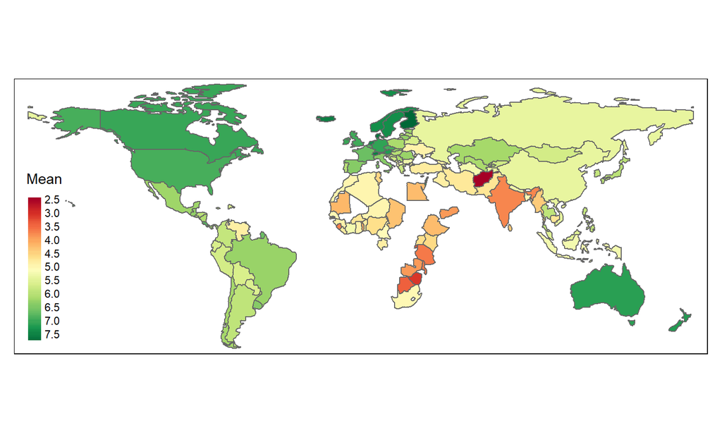

Gli stati più felici risultano essere ancora quelli del Nord Europa.

**Andamento della felicità media mondiale dopo il COVID-19**

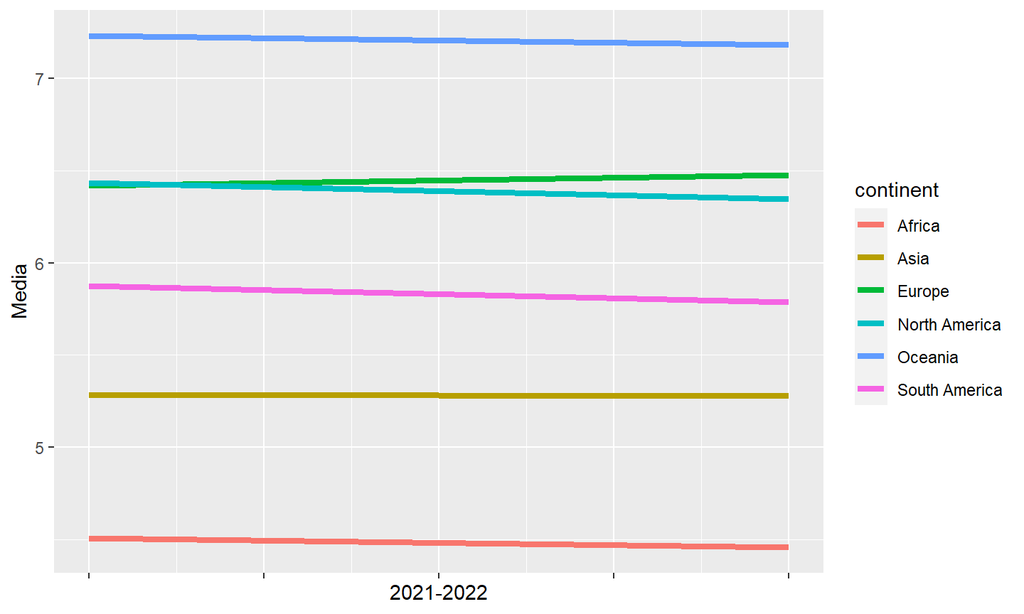

Solo l’Europa risulta aver avuto un incremento mentre gli altri continenti hanno avuto tutti un lieve decremento.

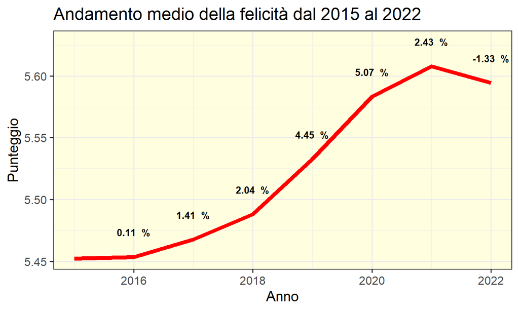

La felicità è diminuita del -1,33% nell’ultimo anno.

**Matrice di correlazione**

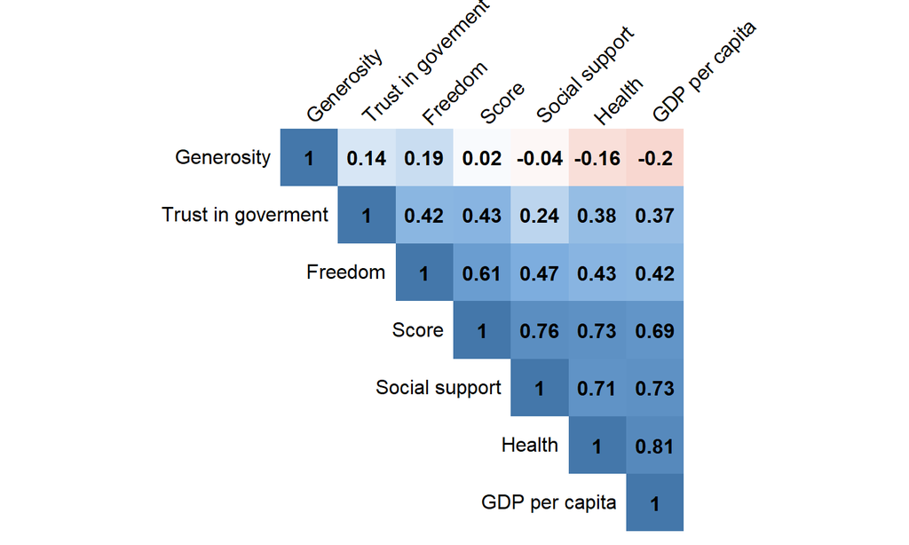

Nel periodo dopo l’avvento del COVID-19 i 3 fattori che influenzano maggiormente lo score della felicità risultano essere:

- supporto sociale
- salute
- GDP per capita